# record_collection_analysis

## Final Project Report: DTSC 5301

My name is Lucas Derr and my domain presentation was on the music industry. For this project I will be analyzing my Dad's large record collection and extracting insights from it. My dad has documented his entire collection on [Discogs](https://www.discogs.com), an online record collection marketplace/hub. [Here](https://www.discogs.com/user/hackerofslop) is a link to his account. I will use the API to load his collection into memory and try to extract insights from it.

```python
import requests
import pandas as pd
from collections import Counter
from itertools import chain
import matplotlib.pyplot as plt
```

```python
token = "RGNNFOqGfjbHiQYPkFesuijUilrAOMEKorYTcVbv"  # I asked my Dad to generate a token for his account
username = 'hackerofslop'
api_url = f'https://api.discogs.com/users/{username}/collection/folders/0/releases?per_page=100&sort=artist'


headers = {
    'Authorization': f'Discogs token={token}'
}
all_albums = []
page = 1

while True:
    api_url = f'https://api.discogs.com/users/{username}/collection/folders/0/releases?page={page}'

    response = requests.get(api_url, headers=headers)

    if response.status_code == 200:

        data = response.json()

        albums_on_page = data['releases']

        all_albums.extend(albums_on_page)

        # Discogs uses pagination, so we have to iterate through his collection page by page
        if 'pagination' in data and 'urls' in data['pagination']:

            if "next" not in data['pagination']['urls']:
                break  # No more pages to fetch
            else:
                next_page_url = data['pagination']['urls']['next']
        else:
            break  # Pagination information is missing
    else:
        print(f"Request failed with status code: {response.status_code}")
        break

    # Increment the page number for the next request
    page += 1

print(f"Total albums owned by {username}: {len(all_albums)}")
```

```
Total albums owned by hackerofslop: 2334
```

Great! My Dad owns 2334 records. Let's convert this list of dictionary objects into a pandas dataframe.

```python
data = {}
data['date_added'] = []
data['rating'] = []
for record in all_albums:

    data['date_added'].append(record['date_added'])
    data['rating'].append (record['rating'])

    info = record['basic_information']
    for key in info:
        if key in data:
            data[key].append(info[key])
        else:
            data[key] = [info[key]]

df = pd.DataFrame(data)
df.head()
```

|  | date_added | rating | id | master_id | master_url | resource_url | thumb | cover_image | title | year | formats | artists | labels | genres | styles |
| --- | --- | --- | --- | --- | --- | --- | --- | --- | --- | --- | --- | --- | --- | --- | --- |
| 0 | 2020-01-19T22:58:22-08:00 | 0 | 4467410 | 568845 | https://api.discogs.com/masters/568845 | https://api.discogs.com/releases/4467410 | https://i.discogs.com/_Woh8K7MAaEkBYJ26NurdhDX... | https://i.discogs.com/pzYLb1laDx3_SkgxgPWhJjBD... | Tired Of Losing | 2001 | [{'name': 'Vinyl', 'qty': '1', 'text': 'Grey M... | [{'name': 'The Mud City Manglers', 'anv': '', ... | [{'name': '007 Records', 'catno': '007 #22', '... | [Rock] | [Rock & Roll, Punk] |
| 1 | 2020-01-19T22:43:50-08:00 | 0 | 5378378 | 99555 | https://api.discogs.com/masters/99555 | https://api.discogs.com/releases/5378378 | https://i.discogs.com/c6FIGkmjFRkLs4IEPdJzobHK... | https://i.discogs.com/VtAZJHhU_TIpzAu0_WMqPIcH... | Hate The Police | 2012 | [{'name': 'Vinyl', 'qty': '1', 'text': 'Clear'... | [{'name': 'Dicks', 'anv': 'The Dicks', 'join':... | [{'name': '1-2-3-4 Go! Records', 'catno': 'GO-... | [Rock] | [Punk] |
| 2 | 2020-01-19T22:39:58-08:00 | 0 | 4655859 | 241574 | https://api.discogs.com/masters/241574 | https://api.discogs.com/releases/4655859 | https://i.discogs.com/vW2xJMa3Z4tiX6wLaiBFnyQx... | https://i.discogs.com/hOBJTOV2Le2Da7ACsrBlHMj8... | Livin' In The 80's | 2013 | [{'name': 'Vinyl', 'qty': '1', 'descriptions':... | [{'name': 'Zero Boys', 'anv': '', 'join': '', ... | [{'name': '1-2-3-4 Go! Records', 'catno': 'GO-... | [Rock] | [Punk] |
| 3 | 2020-01-11T03:06:24-08:00 | 0 | 3804070 | 566119 | https://api.discogs.com/masters/566119 | https://api.discogs.com/releases/3804070 | https://i.discogs.com/ognOf2svwwzLbirc3gX2JCTs... | https://i.discogs.com/GNpoUOs6unSGCvJDcGL9-Eep... | I'm Bleeding Now | 2012 | [{'name': 'Vinyl', 'qty': '1', 'descriptions':... | [{'name': 'Obnox', 'anv': '', 'join': '', 'rol... | [{'name': '12XU', 'catno': '039-1', 'entity_ty... | [Rock] | [Space Rock, Noise] |
| 4 | 2020-01-12T05:25:57-08:00 | 0 | 3590982 | 1247704 | https://api.discogs.com/masters/1247704 | https://api.discogs.com/releases/3590982 | https://i.discogs.com/TIH0TClPWgcd0vGqELrfGyzj... | https://i.discogs.com/JypnP3RqRq5rGudEY7YvrtlQ... | Bring Beer | 2012 | [{'name': 'Vinyl', 'qty': '1', 'text': 'Transl... | [{'name': 'Various', 'anv': '', 'join': '', 'r... | [{'name': '12XU', 'catno': '12XU 036-1', 'enti... | [Rock] | [Garage Rock, Punk, Experimental] |

```python
df['rating'].value_counts() # unfortunately all his records are unrated
```

```
0    2334
Name: rating, dtype: int64
```

```python
genre_counts = Counter(chain.from_iterable(df['genres']))
genre_counts
```

```
Counter({'Rock': 1888,
         'Pop': 147,
         'Folk, World, & Country': 289,
         'Stage & Screen': 23,
         'Jazz': 157,
         'Reggae': 12,
         'Blues': 129,
         'Funk / Soul': 121,
         'Electronic': 53,
         'Latin': 2,
         'Non-Music': 2,
         'Hip Hop': 1,
         'Classical': 2})
```

I don't like this `genre` variable because it clumps almost everything into the rock genre. Let's use the `styles` variable instead.

```python
styles_counts = Counter(chain.from_iterable(df['styles']))
styles_counts
```

```
Counter({'Rock & Roll': 208,
         'Punk': 479,
         'Space Rock': 6,
         'Noise': 36,
         'Garage Rock': 315,
         'Experimental': 45,
         'Blues Rock': 140,
         'Psychedelic Rock': 129,
         'Alternative Rock': 209,
         'Country': 181,
         'Ballad': 21,
         'Vocal': 25,
         'Country Rock': 121,
         'Pop Rock': 197,
         'Death Metal': 14,
         'Funeral Doom Metal': 1,
         'Folk Rock': 150,
         'Power Pop': 48,
         'Soundtrack': 18,
         'Chanson': 4,
         'Folk': 53,
         'New Wave': 88,
         'Art Rock': 54,
         'Indie Rock': 155,
         'Lo-Fi': 45,
         'Soft Rock': 28,
         'Avant-garde Jazz': 3,
         'Classic Rock': 119,
         'Prog Rock': 40,
         'Glam': 37,
         'Hard Rock': 120,
         'Symphonic Rock': 4,
         'Arena Rock': 6,
         'Ska': 3,
         'Easy Listening': 6,
         'Free Jazz': 8,
         'Jazz-Rock': 14,
         'AOR': 8,
         'Modal': 22,
         'Hardcore': 89,
```

[output cut: 107 more lines]

```
         'Industrial Metal': 3,
         'Dixieland': 1,
         'Ragtime': 1,
         'Crust': 5,
         'Melodic Death Metal': 1,
         'Crossover thrash': 1,
         'Dialogue': 1,
         'Field Recording': 1,
         'Twist': 1,
         'Jangle Pop': 1,
         'Western Swing': 1,
         'Contemporary R&B': 1,
         'Zydeco': 1,
         'Cajun': 2,
         'Neofolk': 1})
```

Let's visualize the most common genres in my Dad's record collection.

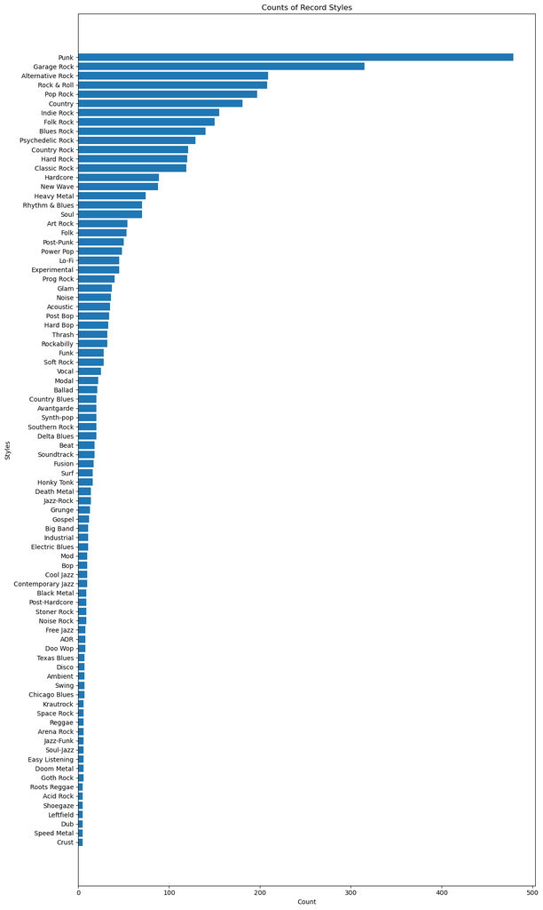

```python
styles_counts_df = pd.DataFrame.from_dict(styles_counts, orient='index', columns=['count'])

styles_counts_df = styles_counts_df[styles_counts_df['count'] >= 5]
styles_counts_df = styles_counts_df.sort_values(by='count', ascending=True)

# Create a long vertical bar chart
plt.figure(figsize=(12, 20))  # Increase the height of the figure
plt.barh(styles_counts_df.index, styles_counts_df['count'])  # Use barh for horizontal bars
plt.xlabel('Count')
plt.ylabel('Styles')
plt.title('Counts of Record Styles')
plt.tight_layout()

# Show the plot
plt.show()
```

Let's do the same thing but look at distribution of the `year` variable.

```python
df['year'].value_counts()
```

```
0       145
1977     78
1978     78
1980     68
1975     62
       ...
1963      2
1959      2
1955      1
1956      1
1954      1
Name: year, Length: 69, dtype: int64
```

Let's investigate why some albums' year is equal to 0.

```python
no_year = df[df['year'] == 0]
print(no_year[['title', 'artists', 'master_url']])
```

```
                                                  title  \
28                                            Doolittle
48                                    Zenyatta Mondatta
73                                  Best Of The Animals
84                                                Split
88    All Tore Up ... Unrequited Love, Tormented Rom...
...                                                 ...
2227                                       Bird And Diz
2249                                       School's Out
2262                                           Montrose
2292                                    American Beauty
2302                        The Bonniwell Music Machine

                                                artists  \
28    [{'name': 'Pixies', 'anv': '', 'join': '', 'ro...
```

[output cut: 25 more lines]

From what I can tell, my Dad has a unique version of the record which does not have a year recorded in the Discogs database. I could scour the API more to add the missing years, but I am lazy, so I am just gonna remove these values.

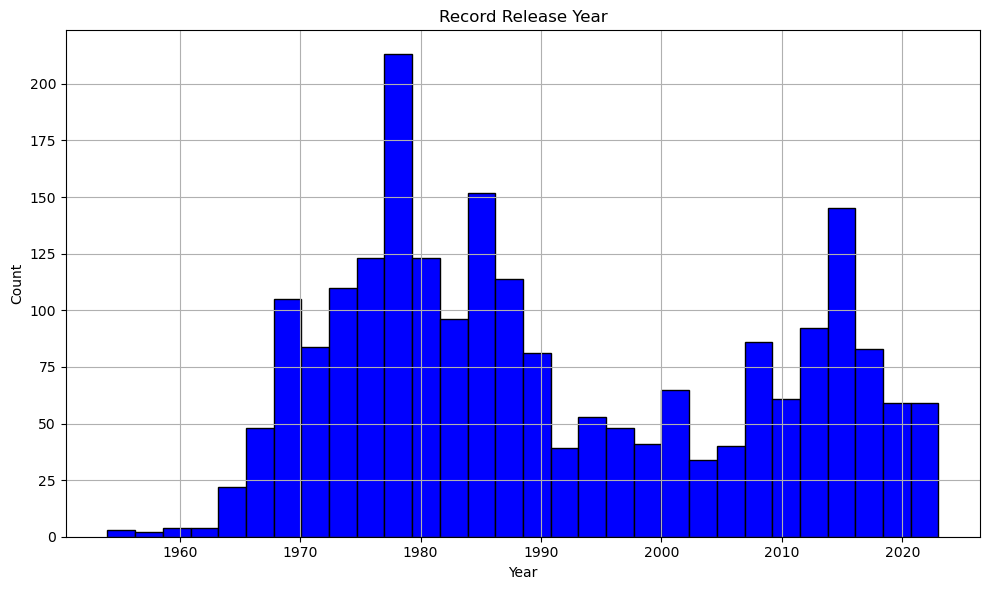

```python
years = df[df['year'] != 0]['year']
plt.figure(figsize=(10, 6))
plt.hist(years, bins=30, color='blue', edgecolor='black')  # Adjust the number of bins as needed
plt.xlabel('Year')
plt.ylabel('Count')
plt.title('Record Release Year')
plt.grid(True)
plt.tight_layout()

# Show the histogram
plt.show()
```

Wow! I was not expecting this distribution to be bimodal! Let's create a separate graph for each style.

```python
no_style = df[df['styles'].apply(len) == 0]
len(no_style)
```

```
105
```

Looks like 105 records have an empty `styles` list.

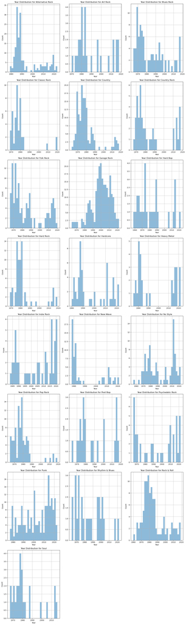

```python
def get_primary_style(styles_list):
    if len(styles_list) == 0:
        return "No Style"
    else:
        return styles_list[0]

df['primary_style'] = df['styles'].apply(get_primary_style)


genre_groups = df.groupby('primary_style')


# only include genres with 15 or more values
genre_groups = {genre: group for genre, group in genre_groups if len(group) >= 20}

num_rows = (len(genre_groups) + 2) // 3
num_cols = min(len(genre_groups), 3)


fig, axes = plt.subplots(num_rows, num_cols, figsize=(15, 50))

axes = axes.flatten()

for i, genre in enumerate(genre_groups):
    group_data = genre_groups[genre]
    group_data = group_data[group_data['year'] != 0]
    ax = axes[i]
    ax.hist(group_data['year'], bins=30, alpha=0.5)
    ax.set_xlabel('Year')
    ax.set_ylabel('Count')
    ax.set_title(f'Year Distribution for {genre}')
    ax.grid(True)

for i in range(len(genre_groups), num_rows * num_cols):
    fig.delaxes(axes[i])

# Adjust the  and spacing
plt.tight_layout()

# Show the subplots
plt.show()
```

Interestingly, a lot of the rock genres have a similar distribution. Most records are either from the 70s and 80s or the 2010s. I just asked my dad about this and he said it is because he mostly bought CDs during this time period.

Let's get the top artists by genre!

```python
df['artist'] = df['artists'].apply(lambda x: x[0]['name'])

# Count the occurrences of each artist within each genre
artist_genre_counts = df.groupby(['primary_style', 'artist']).size().reset_index(name='count')

# Sort the counts within each genre
sorted_artist_genre_counts = artist_genre_counts.sort_values(['primary_style', 'count'], ascending=[True, False])

print("Top Artists by Genre:")
for genre in sorted_artist_genre_counts['primary_style'].unique():
    print(f"\n{genre}:")
    genre_artists = sorted_artist_genre_counts[sorted_artist_genre_counts['primary_style'] == genre]
    for i , (index, row) in enumerate(genre_artists.iterrows()):
        print(f"{i + 1}. {row['artist']}: {row['count']}")
        if i >= 4:  # Show the top 5 artists per genre
            break
```

```
Top Artists by Genre:

AOR:
1. Bob Seger And The Silver Bullet Band: 1
2. Randy Newman: 1

Acid Rock:
1. Chrome (8): 1
2. The Who: 1
3. Various: 1

Acoustic:
1. Neil Young: 3
2. Bob Forrest: 1
3. Brother JT: 1
4. Bruce Springsteen: 1
5. Eddie Money: 1

African:
1. Songhoy Blues: 1
2. William Onyeabor: 1

Alternative Rock:
1. Iggy Pop: 7
2. Various: 7
3. Hüsker Dü: 5
4. Dinosaur Jr.: 4
5. Divine Horsemen: 4

Arena Rock:
1. Blue Öyster Cult: 1
2. Journey: 1
3. Queen: 1

Art Rock:
1. David Bowie: 8
2. John Cale: 4
3. Roxy Music: 3
4. Lungfish: 2
5. The Velvet Underground: 2
```

[output cut: 560 more lines]

```
1. Testament (2): 4
2. Metallica: 3
3. Kreator: 2
4. Power Trip (3): 2
5. Slayer: 2

Vocal:
1. Bessie Smith: 1
2. Bobbie Gentry: 1
3. Frank Sinatra: 1
4. Linda Ronstadt: 1
5. The Shangri-Las: 1

Zydeco:
1. Doug Kershaw: 1
```

Now let's use the `master_url` and `resource_url` variables to get more information about each record and add it to the dataframe.

```python
# First let's see what is in this
test_url1 = 'https://api.discogs.com/masters/568845'
r = requests.get(test_url1).json()
for key in r:
    print(f"{key}: {r[key]}\n")
```

```
id: 568845

main_release: 2757164

most_recent_release: 2757164

resource_url: https://api.discogs.com/masters/568845

uri: https://www.discogs.com/master/568845-The-Mud-City-Manglers-Tired-Of-Losing

versions_url: https://api.discogs.com/masters/568845/versions

main_release_url: https://api.discogs.com/releases/2757164

most_recent_release_url: https://api.discogs.com/releases/2757164

num_for_sale: 5

lowest_price: 7.69

images: [{'type': 'secondary', 'uri': '', 'resource_url': '', 'uri150': '', 'width': 280, 'height': 284}]

genres: ['Rock']

styles: ['Rock & Roll', 'Punk']

year: 2001

tracklist: [{'position': 'A', 'type_': 'track', 'title': 'Tired Of Losing', 'duration': ''}, {'position': 'B1', 'type_': 'track', 'title': 'How Do You Know', 'duration': ''}, {'position': 'B2', 'type_': 'track', 'title': 'Untitled', 'duration': ''}]

artists: [{'name': 'The Mud City Manglers', 'anv': '', 'join': '', 'role': '', 'tracks': '', 'id': 1321531, 'resource_url': 'https://api.discogs.com/artists/1321531'}]

title: Tired Of Losing

data_quality: Correct

videos: [{'uri': 'https://www.youtube.com/watch?v=5QrepnWM41Y', 'title': '2001 PITTSBURGH PA PUNK Mud City Manglers Tired Of Losing garage rawk Pennsylvania', 'description': 'This is from the final of 4 straight killers 45s by these folks from 1997-2001. About a decade later, they released a couple …
```

```python
test_url2 = "https://api.discogs.com/masters/1247704"
r = requests.get(test_url2).json()
for key in r:
    print(f"{key}: {r[key]}\n")
```

```
id: 1247704

main_release: 3590982

most_recent_release: 3590982

resource_url: https://api.discogs.com/masters/1247704

uri: https://www.discogs.com/master/1247704-Various-Bring-Beer

versions_url: https://api.discogs.com/masters/1247704/versions

main_release_url: https://api.discogs.com/releases/3590982

most_recent_release_url: https://api.discogs.com/releases/3590982

num_for_sale: 8

lowest_price: 4.0

images: [{'type': 'secondary', 'uri': '', 'resource_url': '', 'uri150': '', 'width': 600, 'height': 600}, {'type': 'secondary', 'uri': '', 'resource_url': '', 'uri150': '', 'width': 600, 'height': 600}, {'type': 'secondary', 'uri': '', 'resource_url': '', 'uri150': '', 'width': 600, 'height': 600}]

genres: ['Rock']

styles: ['Garage Rock', 'Punk', 'Experimental']

year: 2012

tracklist: [{'position': 'A1', 'type_': 'track', 'artists': [{'name': 'Cruddy', 'anv': '', 'join': '', 'role': '', 'tracks': '', 'id': 2018052, 'resource_url': 'https://api.discogs.com/artists/2018052'}], 'title': 'Home From War', 'duration': ''}, {'position': 'A2', 'type_': 'track', 'artists': [{'n…

artists: [{'name': 'Various', 'anv': '', 'join': '', 'role': '', 'tracks': '', 'id': 194, 'resource_url': ''}]

title: Bring Beer

data_quality: Correct
```

For the final analysis, I'll look at the `lowest_price` and `num_for_sale` variables!

```python
import time
from tqdm import tqdm


def get_sale_info(master_url):

    try:
        time.sleep(1)
        r = requests.get(master_url)

        if r.status_code == 200:
            data = r.json()
            lowest_price, num_for_sale = data["lowest_price"], data["num_for_sale"]
            return lowest_price, num_for_sale
        else:
            print(r.status_code)
            return 0,0
    except Exception as e:
        print(f"Error fetching data for {master_url}: {str(e)}")
    return 0, 0

total_requests = len(df)
progress_bar = tqdm(total=total_requests, desc='Progress', unit=' request')
results = []
for master_url in df['master_url']:
    result = get_sale_info(master_url)
    results.append(result)
    progress_bar.update(1)  # Update the progress bar for each request

progress_bar.close()  # Close the progress bar




df['lowest_price'], df['num_for_sale'] = zip(*results)
```

```
Error fetching data for None: Invalid URL 'None': No scheme supplied. Perhaps you meant http://None?
```

[output not shown]

[output not shown]

[output not shown]

[output not shown]

[output not shown]

[output not shown]

[output not shown]

[output not shown]

[output not shown]

[output not shown]

[output not shown]

[output not shown]

[output not shown]

[output not shown]

[output not shown]

[output not shown]

[output not shown]

I am giving up on this. I kept getting 429 status codes for sending too many requests. It is taking too long. Instead I will look at the record labels.

```python
df.iloc[0]['labels']
```

```
[{'name': '007 Records',
  'catno': '007 #22',
  'entity_type': '1',
  'entity_type_name': 'Label',
  'id': 38426,
  'resource_url': 'https://api.discogs.com/labels/38426'}]
```

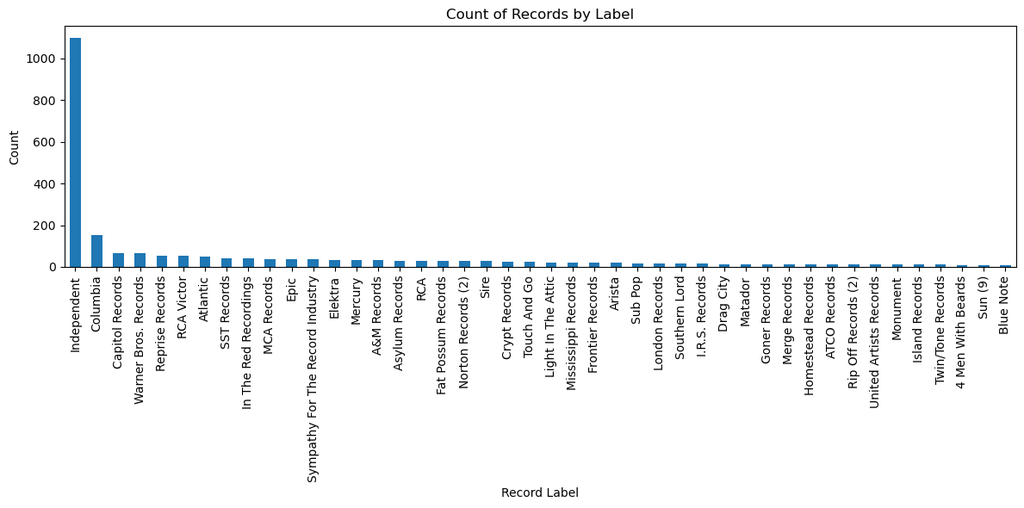

```python
df["record_label"] = df["labels"].apply(lambda x: x[0]['name'])
label_counts = df['record_label'].value_counts()
# Identify labels with fewer than 10 entries
labels_to_combine = label_counts[label_counts < 10].index.tolist()

# Replace labels with fewer than 10 entries with 'independent'
df['record_label'] = df['record_label'].apply(lambda x: 'Independent' if x in labels_to_combine else x)
label_counts = df['record_label'].value_counts()



plt.figure(figsize=(12, 6))
label_counts.plot(kind='bar')
plt.xlabel('Record Label')
plt.ylabel('Count')
plt.title('Count of Records by Label')
plt.xticks(rotation=90)  # Rotate x-axis labels for better readability
plt.tight_layout()
```

Not a whole lot to be said here... I aggregated all labels with fewer than 10 instances and labeled them as independent. We can see the three majors are the top three non-independent labels.